# Demo for estimating entropy production from non-stationary trajectories

*Shun Otsubo*

**Purpose** : Explain how to use LearnEntropy for non-stationary trajectories, and provide the code overview.

**Reference** :  
[1] [Otsubo, Ito, Dechant, and Sagawa, Phys. Rev. E 101, 062106, 2020](https://journals.aps.org/pre/abstract/10.1103/PhysRevE.101.062106)  
[2] [Otsubo, Sreekanth, Sagawa and Krishnamurthy, arXiv:2010.03852, 2020](https://arxiv.org/abs/2010.03852)

### Contents

#### 1. Quick guide

#### 2. Code overview

- Data array
- Objective function
- Neural networks FNNt and FNNKt

## 1. Quick guide

You can estimate the time-dependent entropy production rate and thermodynamic force from non-stationary trajectories. The estimation procedure is almost the same with the stationary case. Please read *demo_stationary.ipynb* first, if you haven't already.  
Here is a minimum demonstration. It may take around ten minutes on a laptop computer.

```python
import main, toy, param, utils
%config InlineBackend.figure_format = 'retina'

data_id = 3
estimate_id = 1
seed = 0

# Generate trajectory data
toy.adaptation(data_id, n_traj = 1000, n_sample=100, dt=10**(-4),
                m_error=0,     # Measurement error (m_error specifies the std of the white noise)
                t_error=0,      # Synchronization error (sampling starts at t = uniform_random(0, t_error))
                rand_seed=seed    # Ensure the reproducibility
               )

# Edit param
param.stationary = False
param.dim = 2
param.dt = 10**(-4)
param.n_traj = 1000
param.t_init = 0
param.t_fin = 0.01
param.x_axis = 0
param.y_axis = 1

param.n_gradient_ascent = 5000
param.which_model = "FNNKt"
param.which_rep = "Simple"
param.which_estimator = "Var"
param.n_layer = 2

# Main program
main.estimate_entropy(data_id, estimate_id, rand_seed=seed)
```

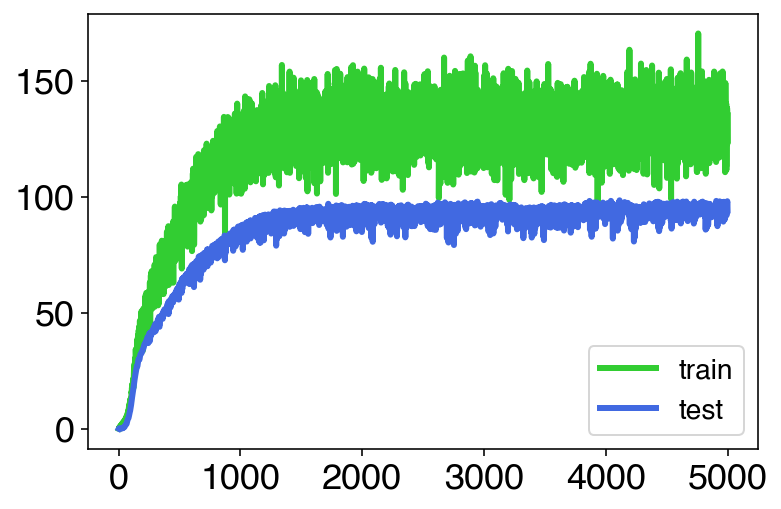

```python
# Plot the learning curve
utils.plot_learning_curve(
    'Result/train' + str(data_id) + '_' + str(estimate_id) + '.txt',
    'Result/test' + str(data_id) + '_' + str(estimate_id) + '.txt'
)
```

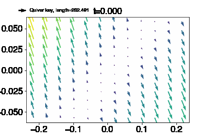

```python
from IPython.core.interactiveshell import InteractiveShell
InteractiveShell.ast_node_interactivity = 'all'
from IPython import display
from pathlib import Path

gifPath = Path('Result/thermo_force'+str(data_id)+'_'+str(estimate_id)+'.gif')

# Show the time-dependent thermodynamic force
with open(gifPath,'rb') as f:
  display.Image(data=f.read(), format='png')
```

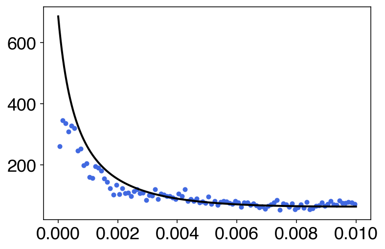

```python
# Plot the time-dependent entropy production rate
utils.plot_epr('Result/epr'+str(data_id)+'_'+str(estimate_id)+'.txt',
               toy.epr_adaptation    # If you know the true entropy production rate function, you can specify it here.
              )
```

```python
'''
We also prepare the breathing parabola model. Please try if you are interested.

Note :
    It may take around ten minuites on a laptop computer.
    The estimated entropy production rate is much biased, since the system is close to the equilibrium and the SN ratio is small.
    The estimate converges to the true entropy production rate if you use a larger number of trajectories.
'''

import main, toy, param, utils
data_id = 4
estimate_id = 1
seed = 0

# Generate trajectory data
toy.breathing_parabola(data_id=4, n_traj = 10**5, n_sample=100, dt=10**(-2),
                       m_error=0,
                       t_error=0,
                       rand_seed=seed
                      )

# Edit param
param.stationary = False
param.dim = 1
param.dt = 10**(-2)
param.n_traj = 10**5
param.t_init = 0
param.t_fin = 1
param.x_axis = 0
param.y_axis = 0

param.n_gradient_ascent = 60
param.which_model = "FNNKt"
param.which_rep = "Simple"
param.which_estimator = "Var"
param.n_layer = 2

# Main program
main.estimate_entropy(data_id, estimate_id, rand_seed=seed)

# Plot the time-depenent entropy production rate
utils.plot_epr('Result/epr'+str(data_id)+'_'+str(estimate_id)+'.txt',
               toy.epr_breathing_parabola
              )
```

## 2. Code overview

In this part, we overview the code by focussing on the difference from the stationary case.

### 2.1. Data array

```python
import numpy as np

data = utils.read_data_file('Data/data' + str(data_id) + '.txt')
train_data, test_data = np.array_split(data, 2, 1)

print(data)
print(data.shape)
```

```
tensor([[[ 5.0000e-05, -3.7060e-02, -1.9084e-02, -4.1884e-04, -1.3473e-03],
         [ 5.0000e-05,  3.5297e-02,  1.7754e-02, -1.1706e-04, -6.5138e-04],
         [ 5.0000e-05, -1.3280e-02, -6.6011e-03, -5.7261e-03,  1.3739e-03],
         ...,
         [ 5.0000e-05, -4.0975e-02, -8.8095e-03,  6.4265e-03,  3.3144e-05],
         [ 5.0000e-05, -8.6853e-02, -2.7764e-02, -6.5279e-03,  2.1276e-04],
         [ 5.0000e-05, -7.6213e-02, -2.5403e-02,  1.5315e-03,  7.7580e-04]],

        [[ 1.5000e-04, -3.7800e-02, -2.0657e-02, -1.0619e-03, -1.7977e-03],
         [ 1.5000e-04,  3.6256e-02,  1.7338e-02,  2.0336e-03, -1.8194e-04],
         [ 1.5000e-04, -1.5664e-02, -6.1827e-03,  9.5671e-04, -5.3691e-04],
         ...,
         [ 1.5000e-04, -4.2684e-02, -8.6979e-03, -9.8449e-03,  1.9008e-04],
         [ 1.5000e-04, -9.0137e-02, -2.7432e-02, -4.1428e-05,  4.4996e-04],
         [ 1.5000e-04, -7.7144e-02, -2.4769e-02, -3.3918e-03,  4.9208e-04]],

        [[ 2.5000e-04, -3.3759e-02, -2.1305e-02,  9.1447e-03,  5.0102e-04],
         [ 2.5000e-04,  4.0479e-02,  1.6633e-02,  6.4141e-03, -1.2272e-03],
         [ 2.5000e-04, -1.2991e-02, -5.7847e-03,  4.3912e-03,  1.3329e-03],
         ...,
         [ 2.5000e-04, -4.0937e-02, -7.1312e-03,  1.3340e-02,  2.9433e-03],
         [ 2.5000e-04, -8.6338e-02, -2.6538e-02,  7.6405e-03,  1.3385e-03],
         [ 2.5000e-04, -8.1090e-02, -2.4971e-02, -4.5003e-03, -8.9701e-04]],

        ...,

        [[ 9.7500e-03, -1.7659e-01, -1.0984e-02,  4.6625e-03,  2.4478e-04],
         [ 9.7500e-03,  3.2227e-02,  9.2298e-03, -3.0305e-03,  2.1696e-04],
         [ 9.7500e-03, -4.8894e-03, -6.9276e-03,  1.1201e-02,  7.5080e-04],
         ...,
         [ 9.7500e-03, -6.8273e-02, -4.6646e-03, -1.2588e-02,  6.9021e-05],
         [ 9.7500e-03, -2.5214e-02, -3.2791e-02,  5.6762e-03, -1.1281e-04],
         [ 9.7500e-03, -2.0606e-02, -4.1807e-03,  3.0002e-02,  4.4238e-04]],

        [[ 9.8500e-03, -1.7343e-01, -1.0024e-02,  1.6453e-03,  1.6750e-03],
         [ 9.8500e-03,  3.4449e-02,  9.4359e-03,  7.4739e-03,  1.9527e-04],
         [ 9.8500e-03,  2.6673e-03, -6.5497e-03,  3.9123e-03,  5.0881e-06],
         ...,
         [ 9.8500e-03, -7.4624e-02, -4.1115e-03, -1.1333e-04,  1.0372e-03],
         [ 9.8500e-03, -3.3311e-02, -3.1996e-02, -2.1870e-02,  1.7009e-03],
         [ 9.8500e-03, -7.4856e-03, -4.0902e-03, -3.7614e-03, -2.6132e-04]],

        [[ 9.9500e-03, -1.7948e-01, -9.5074e-03, -1.3736e-02, -6.4209e-04],
         [ 9.9500e-03,  3.9558e-02,  8.9453e-03,  2.7438e-03, -1.1765e-03],
         [ 9.9500e-03,  1.1585e-02, -6.9428e-03,  1.3923e-02, -7.9136e-04],
         ...,
         [ 9.9500e-03, -7.3846e-02, -3.2496e-03,  1.6690e-03,  6.8666e-04],
         [ 9.9500e-03, -4.3921e-02, -3.0703e-02,  6.5025e-04,  8.8590e-04],
         [ 9.9500e-03, -7.3807e-03, -3.4425e-03,  3.9712e-03,  1.5567e-03]]])
torch.Size([100, 1000, 5])
```

The variable *data* holds an ensemble of single-step transitions as

\begin{eqnarray} \left[\left[\left[\frac{m\Delta t}{2}, \frac{x^0_0 + x^0_{m\Delta t}}{2}, \frac{y^0_0 + y^0_{m\Delta t}}{2}, x^0_{m\Delta t} - x^0_{0}, y^0_{m\Delta t} - y^0_{0}\right], \left[\frac{m\Delta t}{2}, \frac{x^1_0 + x^1_{m\Delta t}}{2}, \frac{y^1_0 + y^1_{m\Delta t}}{2}, x^1_{m\Delta t} - x^1_{0}, y^1_{m\Delta t} - y^1_{0}\right],...\right],\\ \left[\left[\frac{(2n+m)\Delta t}{2}, \frac{x^0_{n\Delta t} + x^0_{(n+m)\Delta t}}{2}, \frac{y^0_{n\Delta t} + y^0_{(n+m)\Delta t}}{2}, x^0_{(n+m)\Delta t} - x^0_{n\Delta t}, y^0_{(n+m)\Delta t} - y^0_{n\Delta t}\right], \left[\frac{(2n+m)\Delta t}{2}, \frac{x^1_{n\Delta t} + x^1_{(n+m)\Delta t}}{2}, \frac{y^1_{n\Delta t} + y^1_{(n+m)\Delta t}}{2}, x^1_{(n+m)\Delta t} - x^1_{n\Delta t}, y^1_{(n+m)\Delta t} - y^1_{n\Delta t}\right],...\right], ...\right] \end{eqnarray}

for a two dimensional case, where $(x^j_{i\Delta t}, y^j_{i\Delta t})$ is the state at time $i\Delta t$ in the $j$th trajectory, $m$ is the current interval (*param.current_interval*), and $n$ is the slice interval (*param.slice_interval*). Unlike the stationary case, the first index (i) of the array (*data[i,j,k]*) specifies the time instance, the second index (j) specifies the trajectory index, and the third index (k) runs over 2*dim+1 elements including the transition time.

## 2. 2. Objective function

In the non-stationary case, we consider to optimize the time-dependent model function using the whole trajectories. For this purpose, we regard a linear combination of the instantaneous variational representations $\widehat{\sigma}(t)$ as an objective function : \begin{eqnarray} f_{\mathcal{T}_k}(\boldsymbol{\theta}) := \sum_{t\in\mathcal{T}_k}a(t)\widehat{\sigma}(t)\Big/\sum_{t\in\mathcal{T}_k} a(t), \end{eqnarray} where $a(t)$ can be any positive values (implemented as *coeff*), and $\mathcal{T}_k$ is a set of time instances ($k$ is implemented as *param.slice_interval*). In our implementation, $a(t)$ is taken from 0 to 1 uniformly randomly at every iteration of the gradient ascent. This might have some advantages over the constant case ($a(t) = 1$), since it serves as the stochastic gradient ascent.

```python
## utils.train() and utils.validate() are explained here

def obj_func(model_func, data, coeff):
    if param.stationary:
        # For the stationary case, s = (x)
        s  = data[:, :, :param.dim]
        dx = data[:, :, param.dim:]
    else:
        # For the non-stationary case, s = (t x)
        s  = data[:, :, :param.dim+1]
        dx = data[:, :, param.dim+1:]

    cur = (model_func(s) * dx).sum(2)

    # coeff is multiplied as the inner product
    if param.which_rep == "Simple":
        ret = torch.matmul(coeff, 2*torch.mean(cur, 1) - torch.var(cur, 1)/2) / (param.dt*param.current_interval)
    elif param.which_rep == "NEEP":
        ret = torch.matmul(coeff, torch.mean(cur-torch.exp(-cur)+1, 1)) / (param.dt*param.current_interval)
    elif param.which_rep == "TUR":
        ret =  torch.matmul(coeff, 2*torch.mean(cur, 1)**2/torch.var(cur, 1)) / (param.dt*param.current_interval)
    print('Objective function :\n     ' + str(ret))
    print()
    return ret


def train(model_func, train_data, optim):
    '''
    This function performs the gradient ascent using training data,
    and returns the value of the objective function.
    '''
    # We introduce stochasticity into coeff
    coeff = np.random.uniform(0, 1, len(train_data)).reshape(1, -1)
    coeff /= coeff.sum()
    coeff = torch.from_numpy(coeff).to(param.device).float()

    model_func.train()
    loss = -obj_func(model_func, train_data, coeff)  # Minus sign is added so that it becomes the loss function
    optim.zero_grad()  # Erase the past gradient
    loss.backward()      # Calculate the gradient for the parameters
    optim.step()           # Parameters are updated on the basis of the gradient
    return float(-loss)


def validate(model_func, data):
    '''
    This function evaluates the model function using training or test data,
    and returns an estimate of the time-averaged entropy production rate.
    '''
    # For the validation, we use a constant coeff to evaluate the model function with equal weight on time.
    coeff = (np.ones(len(data))/len(data)).reshape(1, -1)
    coeff = torch.from_numpy(coeff).to(param.device).float()
    model_func.eval()
    return float(obj_func(model_func, data, coeff))
```

## 2. 3. Neural networks FNNt and FNNKt

We prepared two types of neural networks for the non-stationary case. One is a normal feedforward neural network FNNt (shown in *demo_stationary.ipynb*), and the other is the FNNKt (K comes from kernel function) shown below.

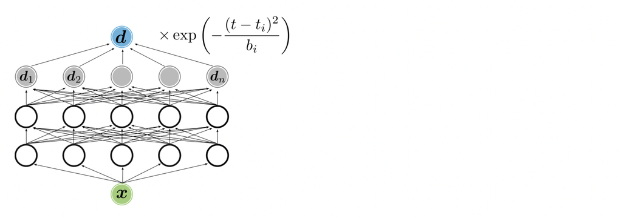

```python
from PIL import Image
im = Image.open('pic/FNNKt.png')
im
```

The FNNKt has time-dependence only in the output layer. Concretely, the output vector $\boldsymbol{d}$ is calculated as follows: $$\boldsymbol{d} = \sum_i \boldsymbol{d}_i \exp\left[-\left(\frac{t-t_i}{b_i}\right)^2\right].$$ We find that the FNNKt shows the better performance. This may be because the FNNKt implicitly assumes that the local thermodynamic force changes at a similar speed for all the position, which is the case for the numerical setups. In practice, we can compare the performance of the FNNt and FNNKt simply by comparing their test values. Note that for the comparison, you should use the same variational representation as that used for the training, and thus you cannot use 'Var' estimator for this purpose.

```python
# FNNKt is explained here

class FNNKt(nn.Module):
    '''
    Feedforward neural network with kernel function for the coefficient d(t, x)
    Input:  time and position
    Output: coefficient

    The input can be an array of (t x), i.e., (dim+1, n_data) tensor.
    Then, the output becomes an array of (d), i.e., (dim, n_data) tensor.
    '''
    def __init__(self):
        super(FNNKt, self).__init__()
        self.n_layer = param.n_layer
        self.n_output = param.n_output
        self.dim = param.dim
        tmp = nn.Sequential()
        tmp.add_module("fc", nn.Linear(param.dim, param.n_hidden))
        tmp.add_module("relu", nn.ReLU(inplace=True))
        setattr(self, "layer1", tmp)
        for i in range(param.n_layer-1):
            tmp = nn.Sequential()
            tmp.add_module("fc", nn.Linear(param.n_hidden, param.n_hidden))
            tmp.add_module("relu", nn.ReLU(inplace=True))
            setattr(self, "layer%d" % (i+2), tmp)
        self.out = nn.Linear(param.n_hidden, param.dim * param.n_output)

        # t_i and b_i  are defined here
        self.out_func_center = nn.Parameter(torch.linspace(param.t_init, param.t_fin, param.n_output).to(param.device))
        self.out_func_width = nn.Parameter((torch.ones(param.n_output) * (param.t_fin - param.t_init)/param.n_output).to(param.device))

    def forward(self, s, correct=1):
        '''
        argument s = (t x)
        correct is for cancelling the constant factor when the short-time TUR is used
        '''
        if s.ndim == 3:
            t = s[:, 0, 0]
            x = s[:, :, 1:]
            for i in range(self.n_layer):
                f = getattr(self, "layer%d" % (i+1))
                x = f(x)

            # The summation is implememented as the inner product
            return torch.einsum('ijkl,il->ijk', self.out(x).reshape(len(s), -1, self.dim, self.n_output),
                                torch.exp(-torch.pow((t.reshape(-1,1)-self.out_func_center.reshape(1,-1))/self.out_func_width.reshape(1,-1), 2))\
) / correct
        else:
            pass
```